# Analisis de Tweets Usuarios Citibanamex

Proyecto: Procesamiento del Lenguaje Natural

Alejandro Rojas Moreno

4/1/2022

# Presentación

Este análisis es de minería de texto, por lo que, la mayoría del trabajo mostrará técnicas estadísticas descriptivas y exploratorias.

Los datos se pueden extraer directamente desde twitter, sin embargo, por comodidad y para seguir el presete trabajo, también, se encuentran en mi repositorio de [github](https://github.com/arojasmor/Quejasbnmx) junto con el código de esta publicación.

# Contenido

- Presentación
- Contenido
- Set up
- Extracción de la información
- Tokenizacion y limpieza de texto
- Análisis exploratorio
  - Distribución temporal de los tweets
  - Frecuencia de palabras
  - Nube de palabras
- Relación entre palabras
- Análisis de sentimientos
- Conclusiones

# Set up

Iniciamos configurando las opciones generales que vamos a requerir para el desarrollo de este proyecto.

```r
knitr::opts_chunk$set(echo = TRUE,
                      warning = FALSE,
                      message = FALSE,
                      fig.align = "center"
                      )

paquetes <- c("rtweet", "tidyverse", "lubridate", "wordcloud", "RColorBrewer", "tidytext", "igraph", "ggraph", "knitr", "DT", "kableExtra", "tm", "reshape2")

instalados <- paquetes %in% installed.packages()

if(sum(instalados == FALSE) > 0) {
  install.packages(paquetes[!instalados])
}

lapply(paquetes, require, character.only = TRUE)
```

# Extracción de de información

La información de los tweets se pueden descargar directamente con apoyo de la función **search_tweets** contenida en el paquete **rtweet**:

```r
# se extraen los tweets
ds <- Map(
  "search_tweets",
  q = "@Citibanamex OR Banamex OR Citibanamex OR banamex OR @banamex",
  n = 5000,
  parse = TRUE,
  include_rts = FALSE,
  lang = "es"
)

# unir los datos
ds <- do_call_rbind(ds)

# se seleccionan columnas
ds <- ds %>%
  select("screen_name",
         "created_at",
         "status_id",
         "text",
         "user_id",
         "verified",
         "location")

# se guarda el archivo
write_csv(ds, "tweets.csv")
```

```r
# se cargan los datos previamente guardados
tweets <- read_csv("tweets.csv")

# se quitan las respuestas de la institución, ya que nos interesan solo los comentarios
# de los clientes
tweets <- tweets %>%
  filter(screen_name !="Citibanamex" & screen_name !="ContactoCitibmx") %>%
  select(c(created_at, text))
```

Se muestra un fragmento de los tweets extraidos:

```r
DT::datatable(head(tweets, 20),
              rownames = FALSE,
              options = list(
                pageLength = 5,
                scrollX = TRUE))
```

| created_at | text |
| --- | --- |
| 2021-12-30T23:41:04Z | @Citibanamex que les pasa?? Estoy muy molesta no tienen acaso ejecutivos para atender en audio matico!! Llevo 1 semana tratando de que un ser humano me atienda. Voy a sucursal y me dice el ejecutivo q… |
| 2021-12-30T23:30:26Z | Sorprendida de lo lento y tedioso que es todo el trámite de la reposición de un plástico en @Citibanamex 😥 |
| 2021-12-30T23:40:32Z | @Citibanamex Ya les envié y jamás me atendieron :/ |
| 2021-12-30T23:09:15Z | Como de costumbre, pésimo el servicio telefónico de @Citibanamex después de varios intentos no logro que nadie me atienda. |
| 2021-12-30T23:39:47Z | @Citibanamex Quiero cancelar una tarjeta pero aunque el servicio telefónico tiene la opción, la selecciono y dice que no está disponible. Entonces para que la ofrecen? |
| 2021-12-30T23:33:52Z | @gateaucocoa Tú nunca trabajaste en alsea carnala, esa es un holding de restaurantes de cadena conocidas, no conozco que relación tiene con citibanamex pero en nuestro proyecto no había relación algun… |
| 2021-12-28T19:03:55Z | SÍNTOMAS TOUR 🔥 PRE-VENTA : cualquier tarjeta @Citibanamex y beneficios de 3,6 y 9 meses sin intereses. 🎟 VENTA GENERAL : todas las tarjetas (cualquier banco) Las dos ventas pueden ser en taquillas, c… |
| 2021-12-29T16:00:44Z | En una hora exactamente empieza la preventa Citibanamex de “Síntomas tour” para Guadalajara y Monterrey. 🙌🏻 |
| 2021-12-28T18:22:18Z | 🎟\| Si tienen tarjeta priority de @Citibanamex al parecer, ya pueden adquirir sus boletos para GDL pero mañana es la PRE-VENTA. https://t.co/p9cZQzLyrw |
| 2021-12-30T23:28:50Z | @alfonsosarab Mañana es la venta general, hoy fue preventa citibanamex ✨ |

[output cut: 10 more lines]

# Tokenizacion y limpieza de texto

En este proyecto, el proceso de limpieza consiste en eliminar del texto todas aquellas palabras, signos, números, abreviaturas, etc., que no aportan información importante.

Además, para poder seguir adelante es necesario tener la información de los comentarios (columna text), en palabras individuales para poder obtener, entre otras cosas sus frecuencias para saber cuáles son las más mencionadas por los usuarios.

```r
source("limpieza.R")

tweets.tkns <- tweets %>%
  mutate(texto_tokenizado = map(.x = text,
                                .f = limpiar_tokenizar))

tweets.tkns %>%
  slice(1) %>%
  select(texto_tokenizado) %>%
  pull()
```

```
## [[1]]
##  [1] "citibanamex" "que"         "les"         "pasa"        "estoy"
##  [6] "muy"         "molesta"     "tienen"      "acaso"       "ejecutivos"
## [11] "para"        "atender"     "audio"       "matico"      "llevo"
## [16] "semana"      "tratando"    "que"         "ser"         "humano"
## [21] "atienda"     "voy"         "sucursal"    "dice"        "ejecutivo"
## [26] "que"         "duda"        "solo"        "puede"       "ser"
## [31] "resuelta"    "audiomatico" "dice"        "que"         "hay"
## [36] "agentes"
```

```r
tweets.tkns <- tweets.tkns %>%
  select(-text) %>%
  unnest()

tweets.tkns <- tweets.tkns %>%
  rename(token = texto_tokenizado)

tweets.tkns %>%
  head(10) %>%
  kbl(
      align = "c",
      caption = "Tokenización",
      ) %>%
  kable_paper("hover", full_width = F)
```

Tokenización

| created_at | token |
| --- | --- |
| 2021-12-30 23:41:04 | citibanamex |
| 2021-12-30 23:41:04 | que |
| 2021-12-30 23:41:04 | les |
| 2021-12-30 23:41:04 | pasa |
| 2021-12-30 23:41:04 | estoy |
| 2021-12-30 23:41:04 | muy |
| 2021-12-30 23:41:04 | molesta |
| 2021-12-30 23:41:04 | tienen |
| 2021-12-30 23:41:04 | acaso |
| 2021-12-30 23:41:04 | ejecutivos |

Como los comentarios están en el idioma Español, se utilizará el paquete **tm** para trabajar con las llamadas stopwords, que son palabras que no aportan valor al análisis como los artículos, conectores, etc.

```r
custom_stop_words <- bind_rows(
                               tibble(word = tm::stopwords("spanish"),
                                          lexicon = "custom"))
tweets.tkns <- tweets.tkns %>%
  rename(word = token,
         fecha = created_at)

tweets.tkns <- anti_join(x = tweets.tkns,
                    y = custom_stop_words,
                    by = "word")

tweets.tkns %>%
  head(10) %>%
  kbl(
      align = "c",
      caption = "Tokenización",
      ) %>%
  kable_paper("hover", full_width = F)
```

Tokenización

| fecha | word |
| --- | --- |
| 2021-12-30 23:41:04 | citibanamex |
| 2021-12-30 23:41:04 | pasa |
| 2021-12-30 23:41:04 | molesta |
| 2021-12-30 23:41:04 | acaso |
| 2021-12-30 23:41:04 | ejecutivos |
| 2021-12-30 23:41:04 | atender |
| 2021-12-30 23:41:04 | audio |
| 2021-12-30 23:41:04 | matico |
| 2021-12-30 23:41:04 | llevo |
| 2021-12-30 23:41:04 | semana |

El resultado de la limpieza y tokenización es un marco de datos de 32,211 filas y 2 columnas:

```r
dim(tweets.tkns)
```

```
## [1] 32211     2
```

# Análisis exploratorio

A continuación, se crearán algunas gráficas que faciliten el análisis exploratorio tanto del comportamiento de los usuarios como del contenido de sus comentarios. Lo anterior, nos dará una primer idea de lo que transmitieron en sus tweets.

## Distribución temporal de los tweets

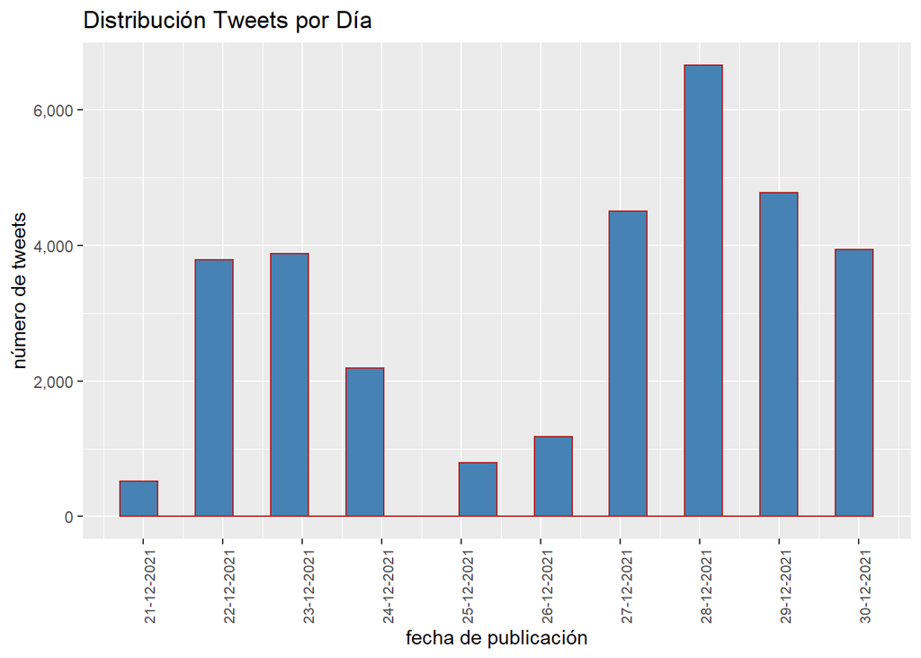

```r
tweets.tkns %>%
  ggplot(aes(x = as.Date(fecha))) +
  geom_histogram(position = "identity",
                 bins = 20,
                 show.legend = FALSE,
                 fill = "steelblue",
                 color = "firebrick") +
  scale_y_continuous(labels = scales::comma) +
  scale_x_date(date_labels = "%d-%m-%Y", date_breaks = "1 day") +
  theme(axis.text.x = element_text(angle = 90, size = 8)) +
  labs(title = "Distribución Tweets por Día", x = "fecha de publicación", y = "número de tweets")
```

En esta primer gráfica se aprecia que los últimos cuatro días del año 2021 hubo una mayor actividad de los usuarios, siendo el día 28 el de mayor cantidad de mensajes.

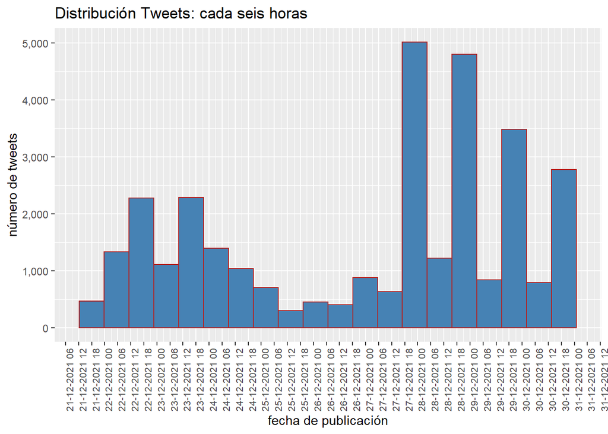

```r
tweets.tkns %>%
  ggplot(aes(x = as.POSIXct(fecha))) +
  geom_histogram(position = "identity",
                 bins = 20,
                 show.legend = FALSE,
                 fill = "steelblue",
                 color = "firebrick") +
  scale_y_continuous(labels = scales::comma) +
  scale_x_datetime(date_labels = "%d-%m-%Y %H", date_breaks = "6 hours") +
   theme(axis.text.x = element_text(angle = 90, size = 8)) +
  labs(title = "Distribución Tweets: cada seis horas",
       x = "fecha de publicación",
       y = "número de tweets")
```

En esta segunda gráfica se muestra la actividad de los usuarios cada seis horas. En ella se observa que en la segunda parte del rango de días analizado la actividad es menor solo que en los últimos 4 días después de las 18:00 horas la actividad crece bastante.

## Frecuencia de palabras

Veamos cuáles son las palabras más utilizadas por los usuarios en sus tweets.

```r
count(tweets.tkns,
      word,
      sort = TRUE) %>%
  head(10) %>%
  kbl(
      align = "c",
      caption = "Tokenización",
      ) %>%
  kable_styling("hover", full_width = F)
```

Tokenización

| word | n |
| --- | --- |
| citibanamex | 2149 |
| banamex | 629 |
| tarjeta | 390 |
| banco | 245 |
| cuenta | 201 |
| hacer | 178 |
| dinero | 171 |
| solo | 150 |
| sucursal | 150 |
| bbva | 149 |

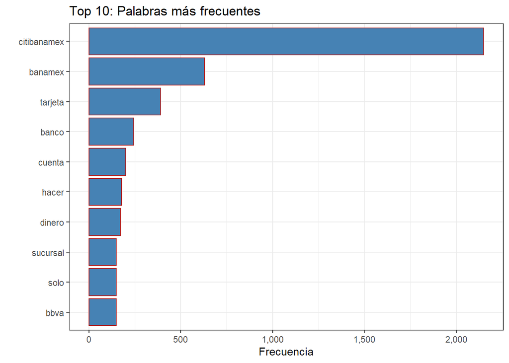

```r
tweets.tkns %>%
  count(word) %>%
  top_n(10, n) %>%
  arrange(desc(n)) %>%
  ggplot(aes(x = reorder(word, n), y = n)) +
  geom_col(fill = "steelblue", color = "firebrick") +
  theme_bw() +
  labs(y = "", x = "") +
  theme(legend.position = "none") +
  scale_y_continuous(labels = scales::comma) +
  coord_flip() +
  labs(title = "Top 10: Palabras más frecuentes",
       y = "Frecuencia")
```

No es de extrañar que las palabras más frecuentes tengan que ver con el nombre de la institución bancaria a la que pertenecen los usuarios cuyos tweets descargamos. También, por las demás palabras parece ser que los comentarios de los usuarios tienen que ver con señalamientos referentes a tarjetas, cuentas, banco, sucursal, etc.

## Nube de palabras

Otra forma de ver las palabras más frecuentes y más utilizada en temas de análisis de texto es la Word Cloud o nube de palabras, la cual es una representación gráfica de la frecuencia y cuyas palabras más importantes (repetidas) tienen mayor tamaño.

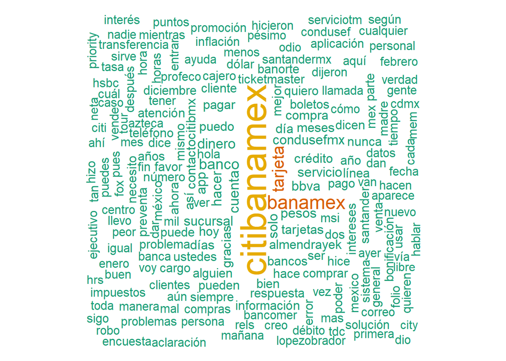

```r
count(tweets.tkns, word) %>%
  with(wordcloud(words = word,
                 freq = n,
                 max.words = 400,
                 scale = c(3,1),
                 rot.per = 0.3,
                 random.order = FALSE,
                 colors = brewer.pal(6, "Dark2")))
```

# Relación entre palabras

Se han hecho descripciones del texto considerando palabras de forma individual que nos han mostrado las más utilizadas por los usuarios, sin embargo, para hacer una descripción un poco más completa y realista es conveniente analizar las palabras en forma conjunta. Lo siguiente que se hará es calcular y visualizar las relaciones entre dos palabras (bigramas).

```r
bigramas <- tweets %>%
  mutate(texto = limpiar(text)) %>%
           select(text) %>%
           unnest_tokens(input = text,
                         output = "bigrama",
                         token = "ngrams",
                         n = 2,
                         drop = TRUE)

bigramas  %>%
  count(bigrama, sort = TRUE) %>%
  head(10) %>%
  kbl(
      align = "c",
      caption = "Tokenización",
      ) %>%
  kable_styling("hover", full_width = F)
```

Tokenización

| bigrama | n |
| --- | --- |
| https t.co | 693 |
| que no | 196 |
| no me | 165 |
| y no | 153 |
| de citibanamex | 152 |
| en el | 151 |
| de la | 146 |
| en la | 136 |
| que me | 128 |
| de banamex | 126 |

Se quitan manualmente algunas palabras que no aportan valor al análisis:

```r
bigramas <- filter(bigramas,
                   bigrama!="https t.co")
```

En el resumen anterior, se aprecia que los bigramas más frecuentes están formados por stopwords, por lo que, se eliminarán por no aportar valor al análisis.

```r
bigramas_separados <- bigramas %>%
  separate(bigrama, c("palabra1", "palabra2"), sep = " ")

head(bigramas_separados)
```

| palabra1 | palabra2 |
| --- | --- |
| citibanamex | que |
| que | les |
| les | pasa |
| pasa | estoy |
| estoy | muy |
| muy | molesta |

```r
# Filtrado de los bigramas que contienen alguna stopword
bigramas_separados <- bigramas_separados  %>%
  filter(!palabra1 %in% custom_stop_words$word) %>%
  filter(!palabra2 %in% custom_stop_words$word)

# Unión de las palabras para formar de nuevo los bigramas
bigramas <- bigramas_separados %>%
            unite(bigrama, palabra1, palabra2, sep = " ")

bigramas %>%
  count(bigrama, sort = TRUE) %>%
  head(20) %>%
  kbl(
      align = "c",
      caption = "Tokenización",
      ) %>%
  kable_styling("hover", full_width = F)
```

Tokenización

| bigrama | n |
| --- | --- |
| almendrayek citibanamex | 77 |
| tarjeta citibanamex | 66 |
| citibanamex https | 56 |
| citibanamex contactocitibmx | 44 |
| citibanamex si | 40 |
| banco azteca | 38 |
| tarjeta banamex | 38 |
| citibanamex hola | 36 |
| pésimo servicio | 32 |
| contactocitibmx citibanamex | 30 |
| citibanamex gracias | 25 |
| puedo hacer | 23 |
| msi https | 22 |
| citibanamex condusefmx | 21 |
| pesos 10 | 21 |
| 2021 https | 19 |
| pesos https | 19 |
| preventa citibanamex | 19 |
| centro citibanamex | 18 |
| mejor fin | 18 |

Una forma más visual e informativa de analizar las relaciones entre las palabras es mediante el uso de redes.

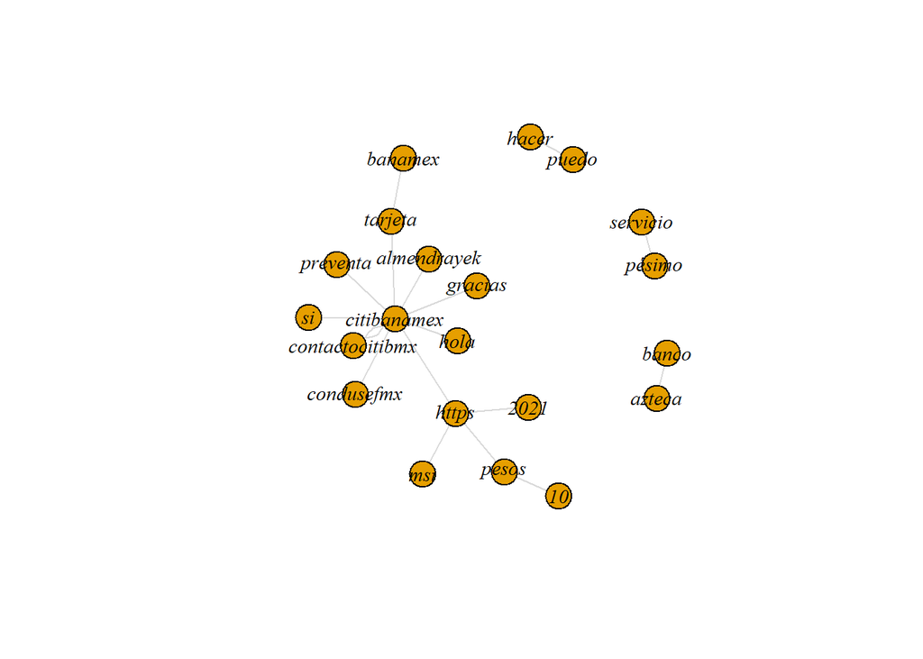

```r
graph <- bigramas %>%
         separate(bigrama, c("palabra1", "palabra2"), sep = " ") %>%
         count(palabra1, palabra2, sort = TRUE) %>%
         filter(n > 18) %>%
  graph_from_data_frame(directed = FALSE)

set.seed(123)

plot(graph, vertex.label.font = 3,
     vertex.label.color = "black",
     vertex.label.cex = 0.9, edge.color = "gray85")
```

Podemos apreciar que dentro del top 10 de los bigramas están:

- **tarjeta citibanamex**
- **banco azteca**
- **pésimo servicio**

Probablemente, las quejas tienen que ver con alguna tarjeta de crédito, con la atención al público tanto en sucursal, vía telefónica y online.

# Análisis de sentimientos

En esta última parte del trabajo se hará el análisis de sentimientos, es decir, se clasificarán las palabras contenidas en los tweets en una de las siguientes dos categorías: positiva o negativa, además, utilizando el lexicon **nrc** se podrán también clasificar las palabras en los siguientes sentimientos: confianza, ira, disgusto, asombro, alegría, miedo, tristeza y premonición.

El archivo de sentimientos se puede descargar del repositorio [github](https://github.com/7PartidasDigital/AnaText/tree/master/datos/diccionarios) del proyecto **7PartidasDigital** elaborado por la Universidad de Valladolid.

```r
source("get_sentiments.R")
sentimientos <- readRDS(file = "sentimientos.rds")

tweets.tkns <- tweets.tkns %>%
  rename(palabra = word)
```

Veamos la cantidad de palabras clasificadas como positivas y negativas de todos los tweets

```r
tweets.tkns %>%
  right_join(get_sentiments("nrc")) %>%
  filter(!is.na(sentimiento) & sentimiento == "positivo" | sentimiento == "negativo") %>%
  count(sentimiento, sort = TRUE) %>%
  kable(
      format = "html",
      digits = 0,
      caption = "Sentimientos Positivos - Negativos",
      format.args = list(big.mark = ","),
      table.attr = "style='width:50%;'") %>%
  kable_styling(bootstrap_options = c("striped", "hover"))
```

Sentimientos Positivos - Negativos

| sentimiento | n |
| --- | --- |
| positivo | 3,960 |
| negativo | 3,824 |

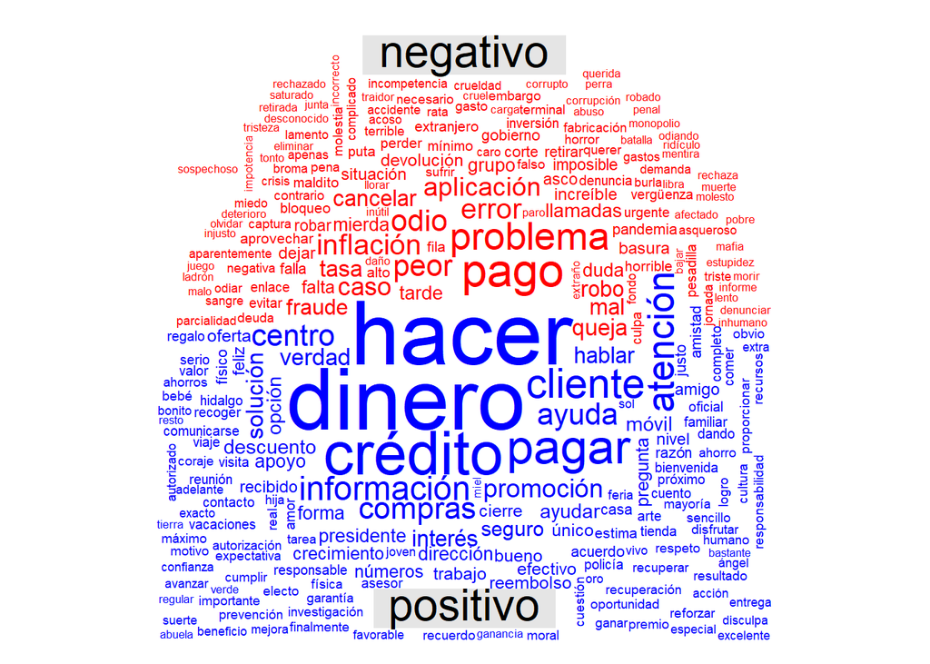

```r
tweets.tkns %>%
  right_join(get_sentiments("nrc")) %>%
  filter(!is.na(sentimiento)& sentimiento == "positivo" | sentimiento == "negativo") %>%
  count(palabra, sentimiento, sort = TRUE) %>%
  acast(palabra ~ sentimiento, value.var = "n", fill = 0) %>%
  comparison.cloud(colors = c("red","blue"),
                   max.words = 300,
                   title.size = 2)
```

En el cuadro anterior, se aprecia que se detectó casi la misma cantidad de palabras negativas que positivas. Ahora, se muestra el detalle (top 15) de las palabras en cada categoría.

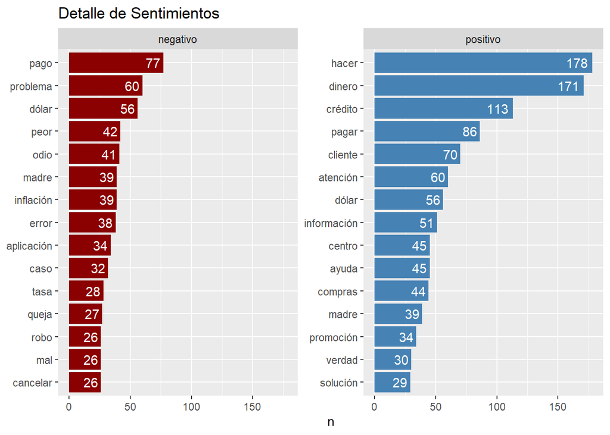

```r
tweets.tkns %>%
  right_join(get_sentiments("nrc")) %>%
  filter(!is.na(sentimiento)& sentimiento == "positivo" | sentimiento == "negativo") %>%
  count(palabra, sentimiento, short = TRUE) %>%
  group_by(sentimiento) %>%
  top_n(15) %>%
  ungroup() %>%
  mutate(palabra = reorder(palabra, n)) %>%
  ggplot(aes(palabra, n, fill = sentimiento)) +
  geom_col(show.legend = FALSE) +
  scale_fill_manual(values = c("darkred", "steelblue")) +
  geom_text(aes(label = n), hjust = 1.2, color = "white") +
  facet_wrap(~sentimiento, scales = "free_y") +
  coord_flip() +
  xlab(NULL) +
  labs(title = "Detalle de Sentimientos")
```

En las gráficas anteriores, se aprecian las palabras que los usuarios capturaron en sus tweets y que el algoritmo los clasificó como negativos o positivos. Las palabras negativas parece que tienen más que ver con reclamos y quejas de los usuarios como robo, mal, peor, cancelar, problema, entre otras.

Ahora, veamos el conteo de los demás sentimientos para darnos una idea del ánimo de los usuarios cuando escribieron sus tweets.

```r
tweets.tkns %>%
  right_join(get_sentiments("nrc")) %>%
  filter(!is.na(sentimiento)) %>%
  count(sentimiento, sort = TRUE) %>%
  kable(
      format = "html",
      digits = 0,
      caption = "Resumen de Sentimientos",
      format.args = list(big.mark = ","),
      table.attr = "style='width:50%;'") %>%
  kable_styling(bootstrap_options = c("striped", "hover"))
```

Resumen de Sentimientos

| sentimiento | n |
| --- | --- |
| positivo | 3,960 |
| negativo | 3,824 |
| confianza | 2,857 |
| miedo | 1,945 |
| tristeza | 1,678 |
| premonición | 1,674 |
| ira | 1,610 |
| disgusto | 1,271 |
| alegría | 1,234 |
| asombro | 941 |

Gráficamente:

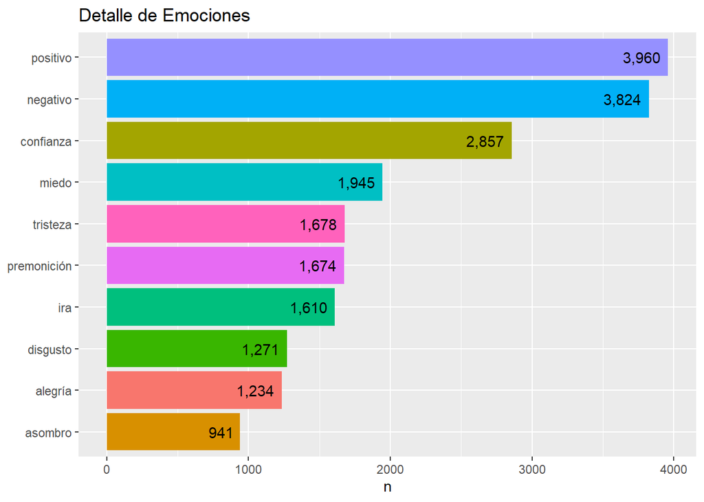

```r
tweets.tkns %>%
  right_join(get_sentiments("nrc")) %>%
  filter(!is.na(sentimiento)) %>%
  group_by(sentimiento) %>%
  count(sentimiento, sort = TRUE) %>%
  mutate(sentimiento = reorder(factor(sentimiento), n)) %>%
  ggplot(aes(reorder(sentimiento,n), n, fill = sentimiento)) +
  geom_col(show.legend = FALSE) +
  geom_text(aes(label = format(n, big.mark = ",")), hjust = 1.2, color = "black") +
  coord_flip() +
  xlab(NULL) +
  labs(title = "Detalle de Emociones")
```

Bajando más el análisis para conocer las palabras contenidas en cada emoción:

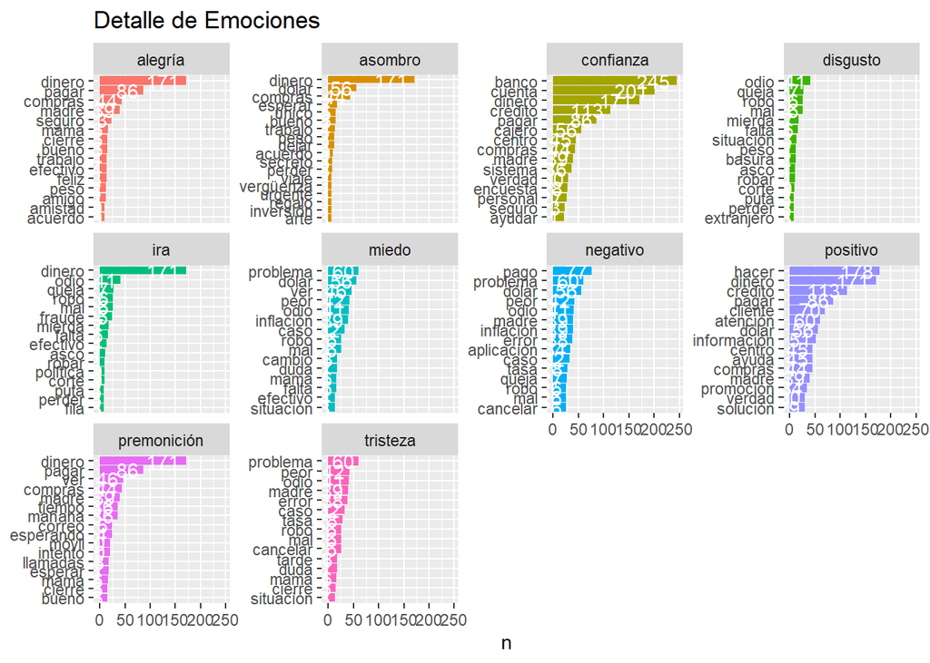

```r
tweets.tkns %>%
  right_join(get_sentiments("nrc")) %>%
  filter(!is.na(sentimiento)) %>%
  count(palabra, sentimiento, short = TRUE) %>%
  group_by(sentimiento) %>%
  top_n(15) %>%
  ungroup() %>%
  mutate(palabra = reorder(palabra, n)) %>%
  ggplot(aes(palabra, n, fill = sentimiento)) +
  geom_col(show.legend = FALSE) +
  geom_text(aes(label = n), hjust = 1.2, color = "white") +
  facet_wrap(~sentimiento, scales = "free_y") +
  coord_flip() +
  xlab(NULL) +
  labs(title = "Detalle de Emociones")
```

Hay algunas palabras que se clasifican en más de una emoción como, por ejemplo, dinero que se encuentra en las categorías de alegría, asombro e ira. Lo anterior, porque depende mucho del contexto de la palabra.

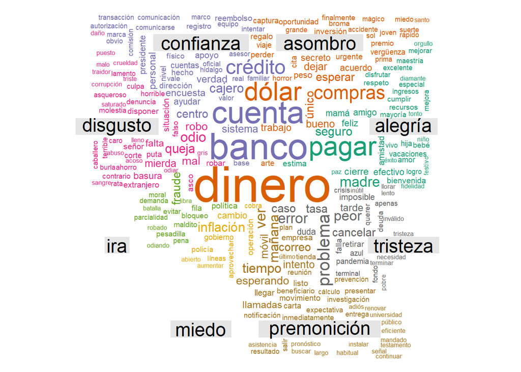

```r
tweets.tkns %>%
  right_join(get_sentiments("nrc")) %>%
  count(palabra, sentimiento, sort = TRUE) %>%
  filter(!is.na(sentimiento), sentimiento != "positivo", sentimiento != "negativo") %>%
  acast(palabra ~ sentimiento, value.var = "n", fill = 0) %>%
  comparison.cloud(title.size = 1.5)
```

# Conclusiones

Después de haber realizado este pequeño análisis podemos concluir que los usuarios de la institución bancaria en cuestión se suelen quejar por temas relacionados con errores en algunas aplicaciones, se sinten robados, pésimo o mal servicio, cancelaciones y con algunos otros problemas que han tenido como clientes.

Hay que aclarar que depende del lexicon o diccionario utilizado los resultados serán distintos.

Con este corto trabajo podemos darnos una idea de lo que el equipo de atención a clientes del banco podría hacer para disminuir los reclamos o quejas como, por ejemplo, realizar encuestas a los clientes que van directamente a sucursal y enviar encuestas vía correo electrónico después de usar algún cajero automático o directamente en su página web. Actualmente, hay empresas que se dedican a proporcionar ese servicio y ya solo le entregan los resultados al cliente, el cual con su equipo o área de analítica se encarga de procesar dicha información para la toma de decisiones.